# Performance

This vignette discusses the performance characteristics of `caugi` including a comparison to the popular [`igraph`](https://r.igraph.org/), [`bnlearn`](https://www.bnlearn.com/), [`dagitty`](https://dagitty.net/), and [`ggm`](https://cran.r-project.org/package=ggm). We focus on the practical trade-offs that arise from different core data structures and design choices.

The headline is: `caugi` frontloads computation. That is, `caugi` spends more effort when constructing a graph and preparing indexes, so that queries are wicked fast. The high performance is also due to the Rust backend.

### Design choices

#### Compressed Sparse Row (CSR) representation

The core data structure in `caugi` is a compressed sparse row (CSR) representation of the graph. CSR representations store for each vertex a contiguous slice of neighbor IDs with a pointer (offset) array that marks the start/end of each slice. This format is memory efficient for sparse graphs. The `caugi` graph object also stores important query information in the object, leading to parent, child, and neighbor queries being done in $\mathcal{O}(1)$. This yields a larger memory footprint, but the trade-off is that queries are extremely fast.

#### Mutation and lazy building

The `caugi` graph objects are expensive to build. This is the performance downside of using `caugi`. For each time we make a modification to a `caugi` graph object, we need to rebuild the graph completely since the graph object is immutable by design. This has complexity $\mathcal{O}(|V| + |E|)$, where $V$ is the vertex set and $E$ is the edge set.

However, the graph object will only be rebuilt when the user either calls `build()` directly or queries the graph. Therefore, you do not need to worry about wasting compute time by iteratively making changes to a `caugi` graph object, as the graph rebuilds lazily when queried. By doing this, `caugi` graphs *feel* mutable, but, in reality, they are not.

By doing it this way, we ensure - that the graph object is always in a consistent state when queried, and - that queries are as fast as possible, while keeping the user experience smooth.

### Comparison

#### Setup

```r
set.seed(42)
```

```r
generate_graphs <- function(n, p) {
  cg <- caugi::generate_graph(n = n, p = p, class = "DAG")
  ig <- caugi::as_igraph(cg)
  ggmg <- caugi::as_adjacency(cg)
  bng <- caugi::as_bnlearn(cg)
  dg <- caugi::as_dagitty(cg)
  list(cg = cg, ig = ig, ggmg = ggmg, bng = bng, dg = dg)
}
```

#### Relational queries

We start with parents/children:

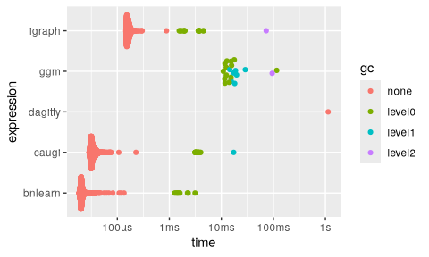

Benchmarking parents/children queries for different packages.

```r
graphs <- generate_graphs(1000, p = 0.25) # dense graph
cg <- graphs$cg
ig <- graphs$ig
ggmg <- graphs$ggmg
bng <- graphs$bng
dg <- graphs$dg

test_node_index <- sample(1000, 1)
test_node_name <- paste0("V", test_node_index)

bm_parents_children <- bench::mark(
  caugi = {
    caugi::parents(cg, test_node_name)
    caugi::children(cg, test_node_name)
  },
  igraph = {
    igraph::neighbors(ig, test_node_name, mode = "in")
    igraph::neighbors(ig, test_node_name, mode = "out")
  },
  bnlearn = {
    bnlearn::parents(bng, test_node_name)
    bnlearn::children(bng, test_node_name)
  },
  ggm = {
    ggm::pa(test_node_name, ggmg)
    ggm::ch(test_node_name, ggmg)
  },
  dagitty = {
    dagitty::parents(dg, test_node_name)
    dagitty::children(dg, test_node_name)
  },
  check = FALSE # igraph returns igraph object
)

plot(bm_parents_children)
```

As you can see, `bnlearn` performs best for this particular example. In our next experiment, however, we will examine if this extends to different graph sizes and densities, by parameterizing our benchmark over `n` and `p`. Note that we adjust `p` as a function of `n` to keep the graphs reasonably sparse.

```r
bm_parents_children_np <-
  bench::press(
    n = c(10, 100, 500, 1000, 5000, 10000),
    p = c(0.5, 0.9),
    {
      p_mod <- 10 * log10(n) / n * p
      graphs <- generate_graphs(n, p = p_mod)
      cg <- graphs$cg
      ig <- graphs$ig
      ggmg <- graphs$ggmg
      bng <- graphs$bng
      dg <- graphs$dg

      test_node_index <- sample(n, 1)
      test_node_name <- paste0("V", test_node_index)

      bench::mark(
        caugi = {
          caugi::parents(cg, test_node_name)
          caugi::children(cg, test_node_name)
        },
        igraph = {
          igraph::neighbors(ig, test_node_name, mode = "in")
          igraph::neighbors(ig, test_node_name, mode = "out")
        },
        bnlearn = {
          bnlearn::parents(bng, test_node_name)
          bnlearn::children(bng, test_node_name)
        },
        ggm = {
          ggm::pa(test_node_name, ggmg)
          ggm::ch(test_node_name, ggmg)
        },
        dagitty = {
          dagitty::parents(dg, test_node_name)
          dagitty::children(dg, test_node_name)
        },
        check = FALSE # igraph returns igraph object
      )
    },
    .quiet = TRUE
  )
```

Next, we plot the benchmark results. As you can see, `bnlearn` performs worse as graph size and density increases, whereas `caugi` is almost unaffected by these parameters, outperforming all other packages when graphs get larger and denser. `dagitty` and `ggm` perform worst overall, quickly becoming infeasible for larger graphs.

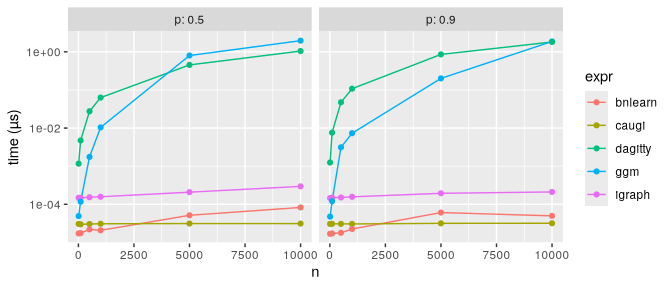

Parameterized benchmarking of parents/children queries.

For ancestors and descendants, we see that `caugi` outperforms all other packages by a several magnitudes, expect for `igraph`, which it still beats, but by a smaller margin:

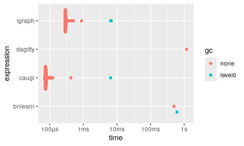

Benchmarking ancestors/descendants queries for different packages.

```r
bm_ancestors_descendants <- bench::mark(
  caugi = {
    caugi::ancestors(cg, "V500")
    caugi::descendants(cg, "V500")
  },
  igraph = {
    igraph::subcomponent(ig, "V500", mode = "in")
    igraph::subcomponent(ig, "V500", mode = "out")
  },
  bnlearn = {
    bnlearn::ancestors(bng, "V500")
    bnlearn::descendants(bng, "V500")
  },
  dagitty = {
    dagitty::ancestors(dg, "V500")
    dagitty::descendants(dg, "V500")
  },
  check = FALSE # dagitty returns V500 as well and igraph returns an igraph
)

plot(bm_ancestors_descendants)
```

#### D-separation

Using the graph from before, we obtain a valid adjustment set and then check for d-separation.

```r
valid_adjustment_set <- caugi::adjustment_set(
  cg,
  "V500",
  "V681",
  type = "backdoor"
)
valid_adjustment_set
```

```
#>   [1] "V7"    "V15"   "V18"   "V24"   "V33"   "V34"   "V68"   "V88"   "V93"
#>  [10] "V121"  "V134"  "V157"  "V168"  "V197"  "V202"  "V206"  "V213"  "V232"
#>  [19] "V262"  "V287"  "V290"  "V291"  "V302"  "V306"  "V314"  "V330"  "V332"
#>  [28] "V342"  "V361"  "V363"  "V368"  "V369"  "V371"  "V385"  "V389"  "V393"
#>  [37] "V409"  "V416"  "V422"  "V425"  "V429"  "V437"  "V444"  "V457"  "V469"
#>  [46] "V476"  "V480"  "V493"  "V504"  "V510"  "V514"  "V522"  "V530"  "V543"
#>  [55] "V555"  "V557"  "V560"  "V564"  "V570"  "V581"  "V588"  "V596"  "V607"
#>  [64] "V620"  "V621"  "V636"  "V641"  "V652"  "V653"  "V660"  "V664"  "V669"
#>  [73] "V673"  "V677"  "V697"  "V701"  "V707"  "V735"  "V743"  "V748"  "V768"
#>  [82] "V785"  "V835"  "V836"  "V844"  "V847"  "V890"  "V893"  "V900"  "V911"
#>  [91] "V912"  "V923"  "V924"  "V927"  "V943"  "V950"  "V964"  "V966"  "V973"
#> [100] "V974"  "V989"  "V991"  "V996"  "V1000"
```

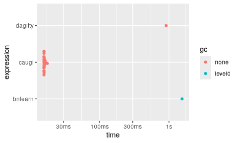

```r
bm_dsep <- bench::mark(
  caugi = caugi::d_separated(cg, "V500", "V681", valid_adjustment_set),
  bnlearn = bnlearn::dsep(bng, "V500", "V681", valid_adjustment_set),
  dagitty = dagitty::dseparated(dg, "V500", "V681", valid_adjustment_set)
)

plot(bm_dsep)
```

#### Subgraph (building)

Here we see an example of where the frontloading hurts performance. When we build a subgraph, we have to rebuild the entire `caugi` graph object. Here, we see that while `caugi` outperforms other packages for queries (except for parents/children for `bnlearn`), it is slower for building the graph objects themselves, which shows in the subgraph benchmark:

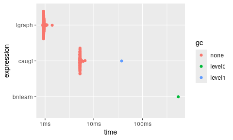

Benchmarking subgraph extraction for different packages.

```r
subgraph_nodes_index <- sample.int(1000, 500)
subgraph_nodes <- paste0("V", subgraph_nodes_index)

bm_subgraph <- bench::mark(
  caugi = {
    caugi::subgraph(cg, subgraph_nodes)
  },
  igraph = {
    igraph::subgraph(ig, subgraph_nodes)
  },
  bnlearn = {
    bnlearn::subgraph(bng, subgraph_nodes)
  },
  check = FALSE
)

plot(bm_subgraph)
```